# Plotting statistics

Robert Schlegel

2017-12-21

# Setup

First install the new package `ggpubr`, which contains the functions we may use to seamless plot output statistics for our figures. We will also load some temperature data to use in our demonstration.

```r
# Libraries
library(tidyverse)
# install.packages("ggpubr")
library(ggpubr)

# Data
SACTN <- read_csv("../data/SACTN_data.csv")
```

# New functions

We will be learning to use two new functions today. The first will be `compare_means()`, which is a function that compares means of two (t-test) or more (ANOVA) groups of values all in one convenient place. The second function is `stat_compare_means()`, which does much the same thing but is designed to be integrated directly into `ggplot2` code.

First we will look at the use of `compare_means()`:

```r
compare_means(temp~site, data = SACTN, method = "anova")
```

```
R> # A tibble: 1 x 6
R>     .y.            p        p.adj p.format p.signif method
R>   <chr>        <dbl>        <dbl>    <chr>    <chr>  <chr>
R> 1  temp 2.55016e-207 2.55016e-207   <2e-16     ****  Anova
```

How snazy is that?! And this works just as well for two mean (t-test) comparisons. It also has built into it the necessary tests for non-parametric comparisons as well as paired tests but we won’t show that explicitrly here.

```r
compare_means(temp~site, data = filter(SACTN, site != "Port Nolloth"), method = "t.test")
```

```
R> # A tibble: 1 x 8
R>     .y.     group1 group2            p        p.adj p.format p.signif
R>   <chr>      <chr>  <chr>        <dbl>        <dbl>    <chr>    <chr>
R> 1  temp Muizenberg Knysna 5.938452e-18 5.938452e-18   <2e-16     ****
R> # ... with 1 more variables: method <chr>
```

This is great, but it is not new functionality, just drasticaly improved functionality. The second function introduced in this package is what is really going to make our lives easier. Here’s why:

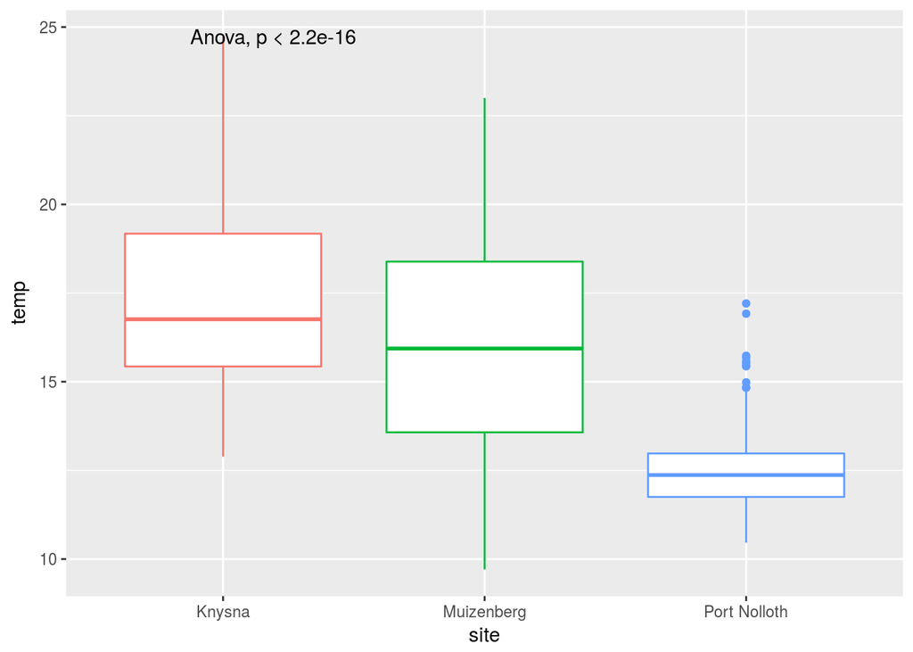

```r
ggplot(data = SACTN, aes(x = site, y = temp)) +
  geom_boxplot(aes(colour = site), show.legend = F) +
  stat_compare_means(method = "anova")
```

I find this to be a very impressive bit of code. The author of this function has devised a way to convince the rather unique `ggplot2` backend to do our dirty work for us and is able to use the x and y axes to calculate statistical analyses. And if that isn’t enough, it then goes and puts it on our figure for us! The future is now. Because this is all still happening within the confines of `ggplot2` code, everything can be changed as we desire. The following is just an example, not necessarily the best way to visualise this information.

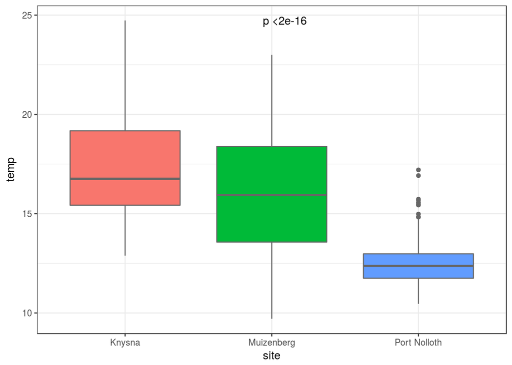

```r
ggplot(data = SACTN, aes(x = site, y = temp)) +
  geom_boxplot(aes(fill  = site), colour = "grey40", show.legend = F) +
  stat_compare_means(method = "anova", aes(label = paste0("p ", ..p.format..)), label.x = 2) +
  theme_bw()
```

# Further applications

As mentioned above, these functions may be used with paired tests, non-parametric tests, and multiple mean tests. These outputs have mates in the `ggplot2` sphere and so may be visualised with relative ease. Below we see an example of how to do this with a multiple mean (ANOVA) test.

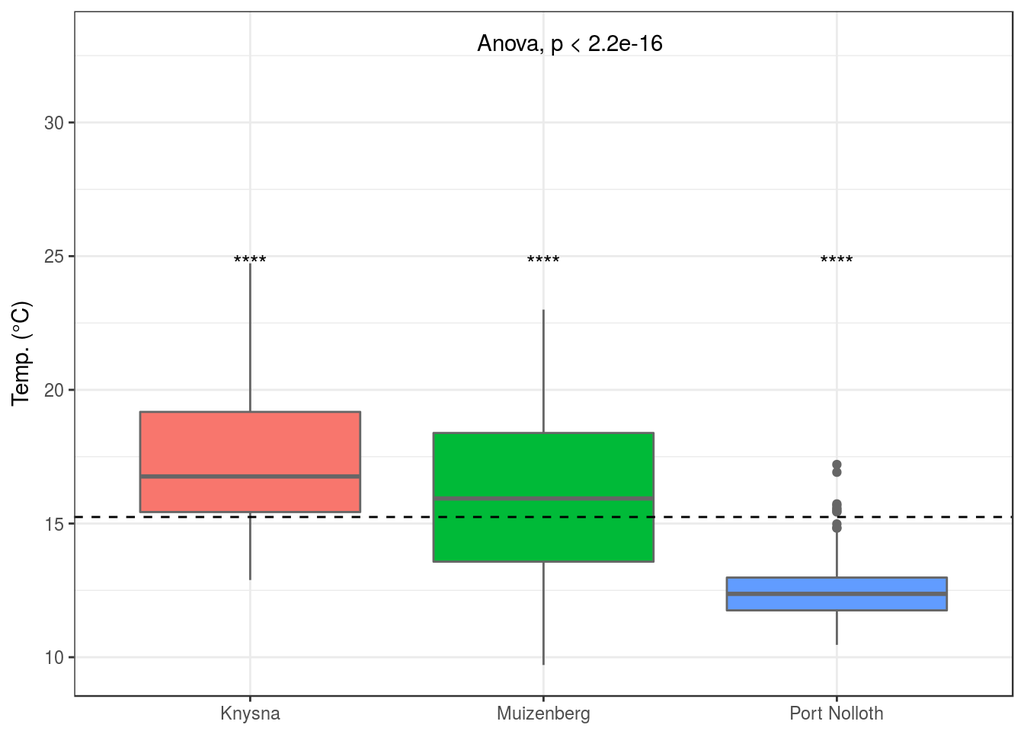

```r
# First create a list of comparisons to feed into our figure
SACTN_levels <- levels(SACTN$site)
my_comparisons <- list( c(SACTN_levels[1], SACTN_levels[2]),
                        c(SACTN_levels[2], SACTN_levels[3]),
                        c(SACTN_levels[1], SACTN_levels[3]))

# And then we wack it all together
ggplot(data = SACTN, aes(x = site, y = temp)) +
  geom_boxplot(aes(fill  = site), colour = "grey40", show.legend = F) +
  stat_compare_means(method = "anova",
                     label.x = 1.9, label.y = 33) +
  # Add pairwise comparisons p-value
  stat_compare_means(comparisons = my_comparisons,
                     label.y = c(26, 28, 30)) +
  # Perform t-tests between each group and the overall mean
  stat_compare_means(label = "p.signif", method = "t.test",
                     ref.group = ".all.") +
  # Add horizontal line at base mean
  geom_hline(yintercept = mean(SACTN$temp, na.rm = T), linetype = 2) +
  labs(y = "Temp. (°C)", x = NULL) +
  theme_bw()
```

For a more detailed explanation for how to perform more advanced comaprisons of multiple groups (especially paired comparisons), and how to plot all of those results in a very cunning way, one may follow this link: https://www.r-bloggers.com/add-p-values-and-significance-levels-to-ggplots/.